# CarD Mtb RNAseq (Kallisto)

Dennis Zhu

9/30/2019

# Part 1 - Data Import & Differential Expression

Loading the R packages that we’ll need.

```r
library(tximport)
library(readr)
library(DESeq2)
```

```r
library(apeglm)
library(pheatmap)
library(ggplot2)
library(factoextra)
library(ggsci)
```

## Importing Data

We can produce a useful table that includes the estimated counts from all of our samples. We’ll call this **CarD_RNAseq_kallisto_counts.csv**. Also in this chunk, we’ll create a directory called **results** that will contain tables produced in this analysis.

```r
#Removing a table from the txi object of just the read counts from each sample
count_table <- txi$counts
count_table <- round(count_table, digits=0)
dir.create("./results")
write.csv(count_table, file="./results/CarD_RNAseq_kallisto_counts.csv")
```

## Running DEseq2

We use the R package DEseq2 to perform our normalization steps and differential expression analysis. The conditions for this experiment are the different CarD mutant genotypes, all of which will be compared back to a Mtb strain expressing WT CarD.

```r
#create a DEseqtable df to tell DEseq the design of your experiment; each file must be described by at least one condition or variable
DEseqtable <- data.frame(condition = factor(rep(c("R47E", "K125A", "I27F", "I27W", "WT"), each = 3), levels = c("WT", "R47E", "K125A", "I27F", "I27W")))

#setting the factor levels to help order them later for visualization
levels(DEseqtable$condition)
```

```
## [1] "WT"    "R47E"  "K125A" "I27F"  "I27W"
```

```r
row.names(DEseqtable) <- colnames(txi$counts)

#print it out to make sure it looks right
DEseqtable
```

```
##         condition
## r47e_1       R47E
## r47e_2       R47E
## r47e_3       R47E
## k125a_1     K125A
## k125a_2     K125A
## k125a_3     K125A
## i27f_1       I27F
## i27f_2       I27F
## i27f_3       I27F
## i27w_1       I27W
## i27w_2       I27W
## i27w_3       I27W
## wt_1           WT
## wt_2           WT
## wt_3           WT
```

```r
#creating the DESeq2 object
dds <- DESeqDataSetFromTximport(txi, DEseqtable, ~condition)
```

```
## using counts and average transcript lengths from tximport
```

Running the normalization steps on our **dds** object, which is the thing that DEseq recognizes.

```r
dds <- DESeq(dds)
```

```
## using 'avgTxLength' from assays(dds), correcting for library size
```

The **results()** function then actually performs the comparisons from the normalized and transformed dds object. We create a results table for each of our 4 mutant genotypes compared to the WT expressing strain.

Ultimately after reading and thinking a little more about it, I think that the best way to approach reporting logFoldChange values is just to apply the recommended **apeglm** effect size shrinkage. Ultimately this is all an estimation, and as long as we report it, there’s no reason to not use the shrinkage.

```r
res_r47e <- lfcShrink(dds, coef="condition_R47E_vs_WT", type="apeglm")
```

```
## using 'apeglm' for LFC shrinkage. If used in published research, please cite:
##     Zhu, A., Ibrahim, J.G., Love, M.I. (2018) Heavy-tailed prior distributions for
##     sequence count data: removing the noise and preserving large differences.
##     Bioinformatics. https://doi.org/10.1093/bioinformatics/bty895
```

```r
res_k125a <- lfcShrink(dds, coef="condition_K125A_vs_WT", type="apeglm")
```

```
## using 'apeglm' for LFC shrinkage. If used in published research, please cite:
##     Zhu, A., Ibrahim, J.G., Love, M.I. (2018) Heavy-tailed prior distributions for
##     sequence count data: removing the noise and preserving large differences.
##     Bioinformatics. https://doi.org/10.1093/bioinformatics/bty895
```

```r
res_i27f <- lfcShrink(dds, coef="condition_I27F_vs_WT", type="apeglm")
```

```
## using 'apeglm' for LFC shrinkage. If used in published research, please cite:
##     Zhu, A., Ibrahim, J.G., Love, M.I. (2018) Heavy-tailed prior distributions for
##     sequence count data: removing the noise and preserving large differences.
##     Bioinformatics. https://doi.org/10.1093/bioinformatics/bty895
```

```r
res_i27w <- lfcShrink(dds, coef="condition_I27W_vs_WT", type="apeglm")
```

```
## using 'apeglm' for LFC shrinkage. If used in published research, please cite:
##     Zhu, A., Ibrahim, J.G., Love, M.I. (2018) Heavy-tailed prior distributions for
##     sequence count data: removing the noise and preserving large differences.
##     Bioinformatics. https://doi.org/10.1093/bioinformatics/bty895
```

A summary of those results.

```r
summary(res_r47e)
```

```
##
## out of 3977 with nonzero total read count
## adjusted p-value < 0.1
## LFC > 0 (up)       : 1415, 36%
## LFC < 0 (down)     : 1418, 36%
## outliers [1]       : 0, 0%
## low counts [2]     : 0, 0%
## (mean count < 0)
## [1] see 'cooksCutoff' argument of ?results
## [2] see 'independentFiltering' argument of ?results
```

```r
summary(res_k125a)
```

```
##
## out of 3977 with nonzero total read count
## adjusted p-value < 0.1
## LFC > 0 (up)       : 1286, 32%
## LFC < 0 (down)     : 1325, 33%
## outliers [1]       : 0, 0%
## low counts [2]     : 0, 0%
## (mean count < 0)
## [1] see 'cooksCutoff' argument of ?results
## [2] see 'independentFiltering' argument of ?results
```

```r
summary(res_i27f)
```

```
##
## out of 3977 with nonzero total read count
## adjusted p-value < 0.1
## LFC > 0 (up)       : 922, 23%
## LFC < 0 (down)     : 1075, 27%
## outliers [1]       : 0, 0%
## low counts [2]     : 0, 0%
## (mean count < 0)
## [1] see 'cooksCutoff' argument of ?results
## [2] see 'independentFiltering' argument of ?results
```

```r
summary(res_i27w)
```

```
##
## out of 3977 with nonzero total read count
## adjusted p-value < 0.1
## LFC > 0 (up)       : 1176, 30%
## LFC < 0 (down)     : 1232, 31%
## outliers [1]       : 0, 0%
## low counts [2]     : 0, 0%
## (mean count < 0)
## [1] see 'cooksCutoff' argument of ?results
## [2] see 'independentFiltering' argument of ?results
```

Extracting a data frame of the results so that we can manipulate the data a little more easily.

```r
df_r47e <- as.data.frame(res_r47e)
df_k125a <- as.data.frame(res_k125a)
df_i27f <- as.data.frame(res_i27f)
df_i27w <- as.data.frame(res_i27w)

gene_id <- row.names(df_r47e)
genotypes <- factor(c("R47E", "K125A", "I27F", "I27W"), levels = c("R47E", "K125A", "I27F", "I27W"))
```

Writing those data frames out to the results folder. Remember that all of these have the apeglm effect size shrinkage applied.

```r
write.csv(df_r47e, file = "./results/res_r47e.csv")
write.csv(df_k125a, file = "./results/res_k125a.csv")
write.csv(df_i27f, file = "./results/res_i27f.csv")
write.csv(df_i27w, file = "./results/res_i27w.csv")
```

# Part 2 - How many genes are differentially expressed?

In this section, I’m asking the question: how many genes are significantly differentially expressed in each of the CarD mutant backgrounds.

```r
r_up <- as.vector(row.names(base::subset(df_r47e, log2FoldChange>0 & padj<0.05)))
r_down <- as.vector(row.names(base::subset(df_r47e, log2FoldChange<0 & padj<0.05)))
r_count <- c(length(r_up), length(r_down), 4031-length(r_up)-length(r_down))
names(r_count) <- c("Up", "Down", "Not Sig")
r_count
```

```
##      Up    Down Not Sig
##    1306    1337    1388
```

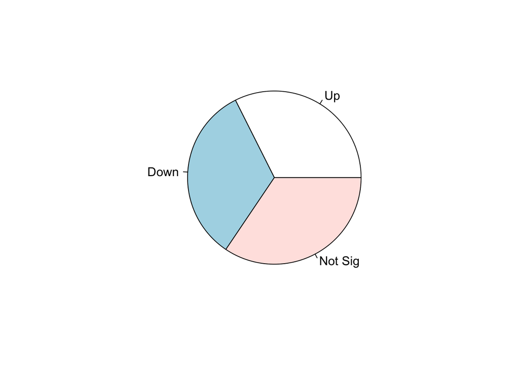

```r
pie(r_count)
```

```r
k_up <- as.vector(row.names(base::subset(df_k125a, log2FoldChange>0 & padj<0.05)))
k_down <- as.vector(row.names(base::subset(df_k125a, log2FoldChange<0 & padj<0.05)))
k_count <- c(length(k_up), length(k_down), 4031-length(k_up)-length(k_down))
names(k_count) <- c("Up", "Down", "Not Sig")
k_count
```

```
##      Up    Down Not Sig
##    1178    1226    1627
```

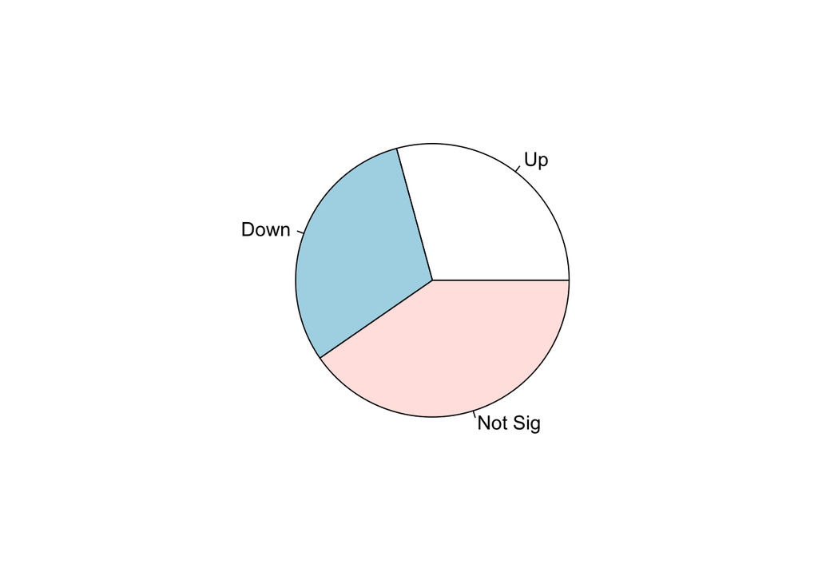

```r
pie(k_count)
```

```r
f_up <- as.vector(row.names(base::subset(df_i27f, log2FoldChange>0 & padj<0.05)))
f_down <- as.vector(row.names(base::subset(df_i27f, log2FoldChange<0 & padj<0.05)))
f_count <- c(length(f_up), length(f_down), 4031-length(f_up)-length(f_down))
names(f_count) <- c("Up", "Down", "Not Sig")
f_count
```

```
##      Up    Down Not Sig
##     803     946    2282
```

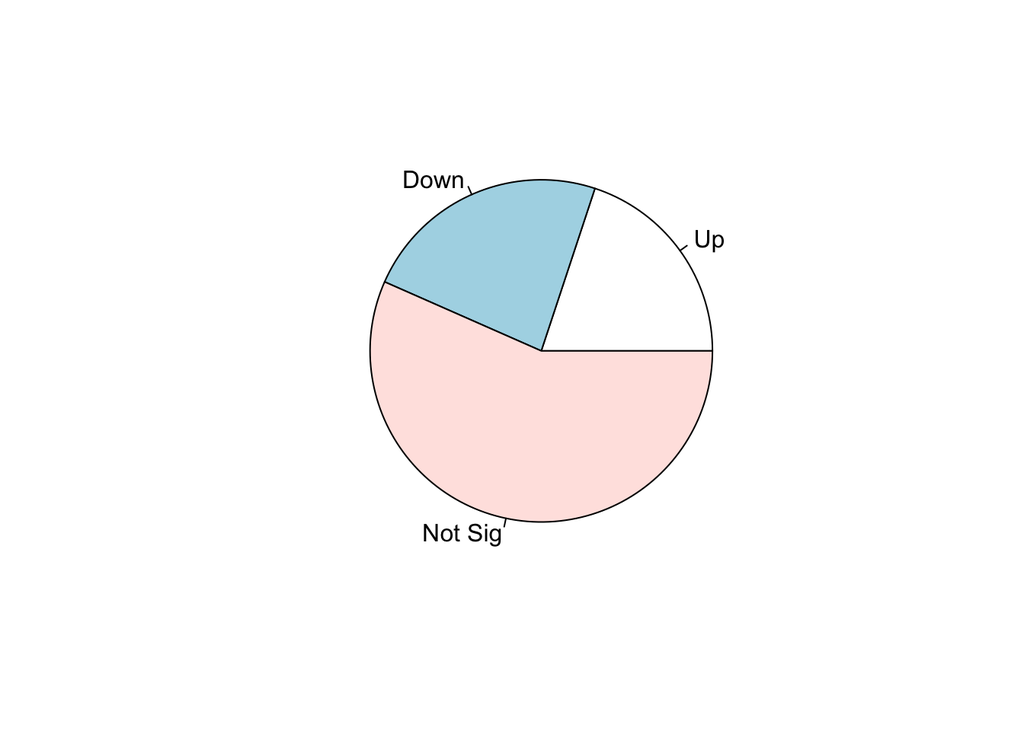

```r
pie(f_count)
```

```r
w_up <- as.vector(row.names(base::subset(df_i27w, log2FoldChange>0 & padj<0.05)))
w_down <- as.vector(row.names(base::subset(df_i27w, log2FoldChange<0 & padj<0.05)))
w_count <- c(length(w_up), length(w_down), 4031-length(w_up)-length(w_down))
names(w_count) <- c("Up", "Down", "Not Sig")
w_count
```

```
##      Up    Down Not Sig
##    1063    1135    1833
```

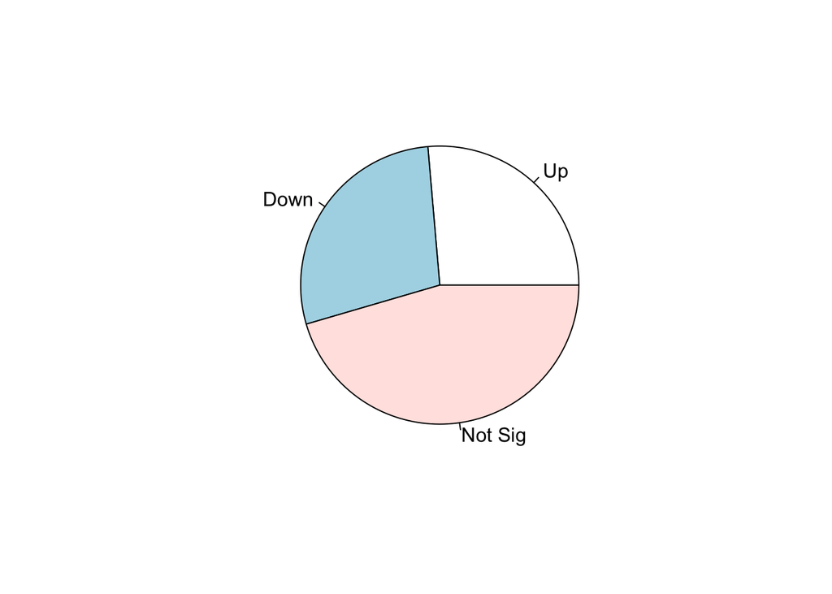

```r
pie(w_count)
```

We can see that a large proportion of the Mtb genome is differentially expressed in each of the CarD mutant strains.

# Part 3 - PCA Analysis and Sample Distance Heatmap

Our next question in this analysis is: What are the relationships between the gene expression patterns of the different CarD mutants?

There are a couple of basic visualizations that will help us answer this question. One simple one is a sample-sample distance heatmap.

Before we get started, we need to transform the data into a data matrix that can be easily handled by the principal component analysis calculations as well as the distance matrix calcultions. We also use the **vst()** function to perform a variance stabilizing transformation on the data matrix.

```r
count_vst <- vst(count_table)
count_vst_t <- t(count_vst)
```

## Sample Distance Heatmap

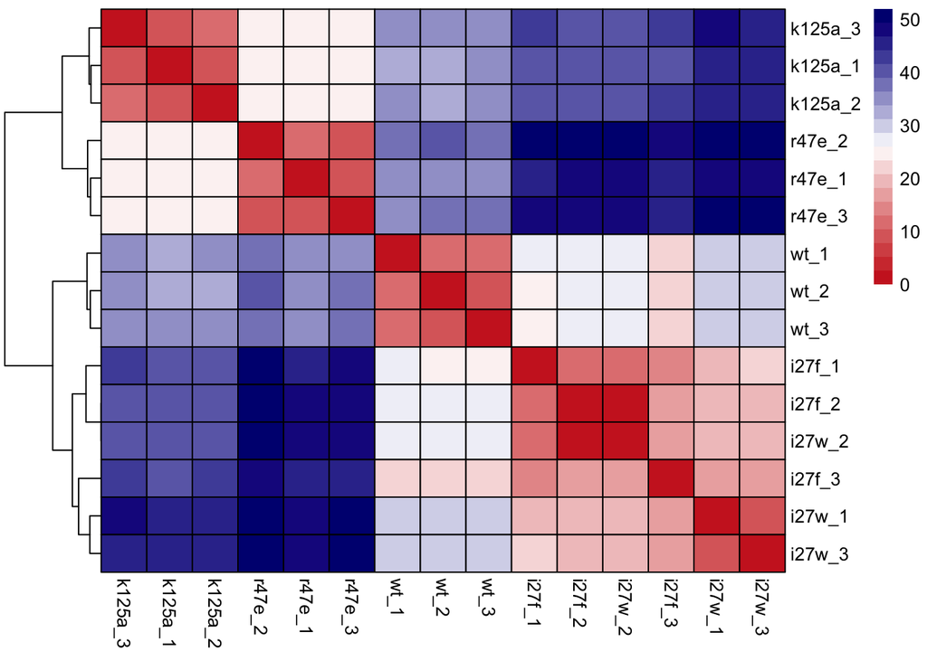

```r
#By default dist() caluclates the Euclidean distance
sample_dist <- dist(count_vst_t, method = "euclidean")
sample_dist.m <- as.matrix(sample_dist)

#use the pheatmap function to create a clustered sample distance heatmap
pheatmap(sample_dist.m, border_color = "black", show_colnames = T, treeheight_col = 0,  color = colorRampPalette(c("firebrick3", "white", "navy"))(20))
```

## PCA

Another way to visualize the gene expression differences between our different CarD mutants is by using a principal component analysis. I use **prmcomp()** function in the base Rstats package to calculate the principal components from our data matrix. Then plot the results using ggplot.

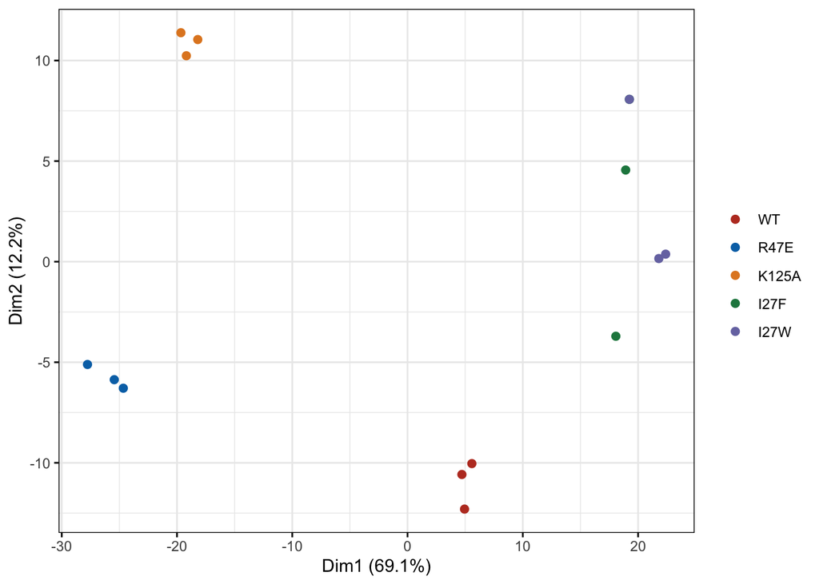

```r
#prcomp() is the PCA function in the base R stats package
pca_res <- prcomp(count_vst_t, scale = F)

#fviz_pca_ind() is a wrapper for ggplot that is specially made for visualizing PCAs
pca_plot <- fviz_pca_ind(pca_res, geom.ind = "point", col.ind=DEseqtable$condition, pointshape=19, pointsize=2, mean.point=F, addEllipses = F, ellipse.type="euclid", axes.linetype="blank") + theme(panel.border = element_rect(fill=NA, color="black"), plot.title = element_blank()) + scale_color_nejm() + theme(legend.position="right", legend.title=element_blank())
pca_plot
```

From the PCA plot, we can see that Dimension 1 explains a large proportion of the variance between samples. Additionally, we can examine the contribution of each variable (the expression of each gene) to PC1. This will help us ask: which specific genes are most responsible for the differences between R47E/K125A vs. I27F/I27W.

We also produce a “Scree plot” using the **fviz_eig()** function, which allows us to see how many “contributing” components the PCA was able to reduce our data down to. Usually the number of dimensions is determined by identifying the “elbow” in the curve. Here it looks like PC1 really is responsible for explaining most of the variance.

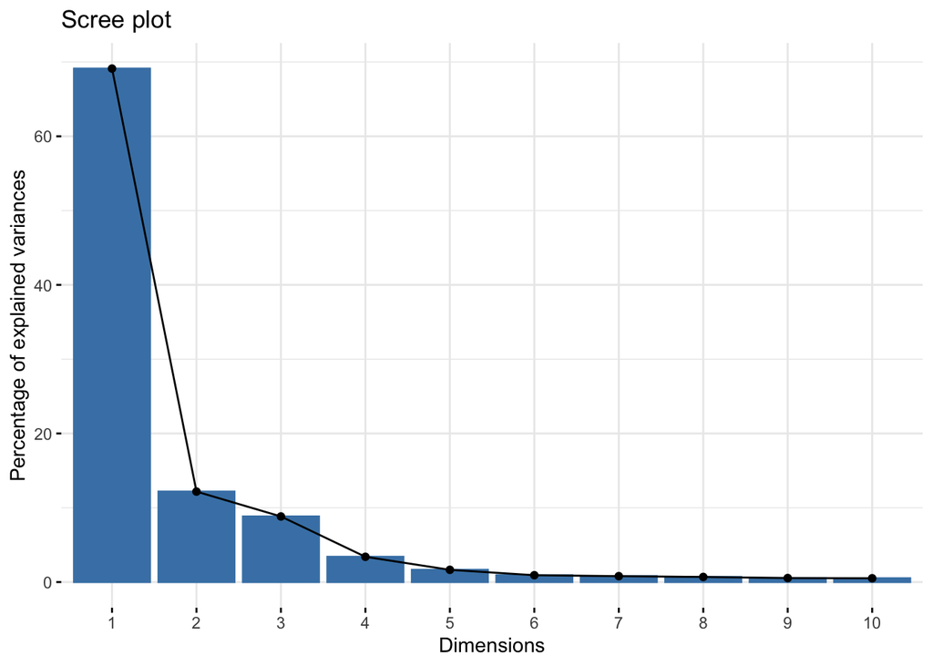

```r
fviz_eig(pca_res)
```

```r
#extract a vector showing the contribution of each of the variables (genes) to PC1
pca_var <- get_pca_var(pca_res)
pca_contrib <- pca_var$contrib
pca_dim1 <- pca_contrib[,1]
pca_dim1_sorted <- base::sort(pca_dim1, decreasing=T)
write.csv(pca_dim1, file="./results/pca_card_dim1.csv")
```